# ch-5_reading_note

Wendy

June 29, 2016

[output not shown]

Comparison is based in the page 210 *still need some cases to practice the bootstrap function*

| Function | Assumption | Assumption2 | Merit |
| --- | --- | --- | --- |
| lm.function | depend on unknow parameter sigma<sup>2</sup>, its estimation by using the RSS, sigma<sup>2</sup> estimation rely on the linear model being correct. | assume the x<sub>i</sub> are fixed, and all the variability comes from the variation in the erroes e<sub>i</sub> | — |
| boot.function | not rely on the assumption | not rely on the assumption2 | more accurate estimate of the standard errors of beta<sub>0</sub> and beta<sub>1</sub> |

### Cross-Validation

#### 1. Valid Set

#### from page 190 lab from 205

**example @ 5.1.1** *purpose:* to check which regression function is better  
*method:* to make split the dataset into two part.  
*result:* the poly(horsepower, 2) show more lower error rate.

```r
library(ISLR)
```

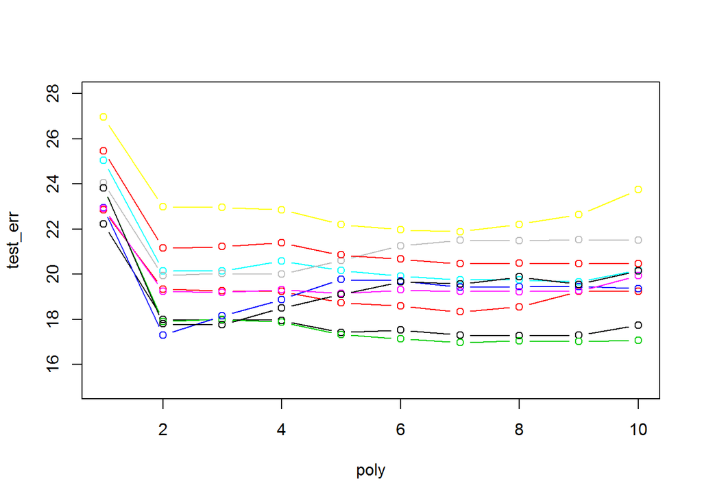

```r
set.seed(1)
set.seed(2)
train_index = sample(c(TRUE, FALSE), size = nrow(Auto), replace = TRUE, prob = c(.5, .5))

# make the plot for n = 1:10 error rate with same train_index
make_poly_1st <- function(n, train_index){
  temp.test_error <- NULL
  poly_num <- NULL

  for (i in 1:n) {
    temp.lm = lm(mpg ~ poly(horsepower, i), data = Auto, subset = train_index)
    temp.lm.pre = predict(temp.lm, Auto[!train_index, ])
    temp.test_error <- c(temp.test_error, mean((Auto[!train_index, "mpg"] - temp.lm.pre)^2))
    poly_num <- c(poly_num, i)

  }

  poly_test_err <- data.frame("poly" = poly_num, "test_err" = temp.test_error)
  return (poly_test_err)
}

# for 10 different train_index, check the n=1:10 error rate.
make_poly_10 <- function(){
  for (i in 1:10){
    set.seed(i)
    train_index <- sample(c(TRUE, FALSE), size = nrow(Auto), replace = TRUE, prob = c(.5, .5))
    if (i == 1)
      {
      temp_data <- make_poly_1st(10, train_index)
      plot(test_err ~ poly, data = temp_data, type = "b", ylim = range(15, 28))
      # print (head(temp_data))
      }
    else
      {
      temp_data <- make_poly_1st(10, train_index)
      lines(temp_data$test_err, type = "b", col = i)
      # print (head(temp_data))
      }

  }
}

make_poly_10()
```

#### 2. Leave One Out CV

##### from page 192

**example @ 5.1.2** *purpose:* to valid the figure 5.4 *method:* random choose one as the test data, and the rest of the data is the training data. *result:* the error is largely variable.  
*notice:* the following method is wrong. the LOOCV should calculate all the records of data, which means, if you have 100 rows of data, you need to do the LOOCV 100 times. Then you could get the error rate.

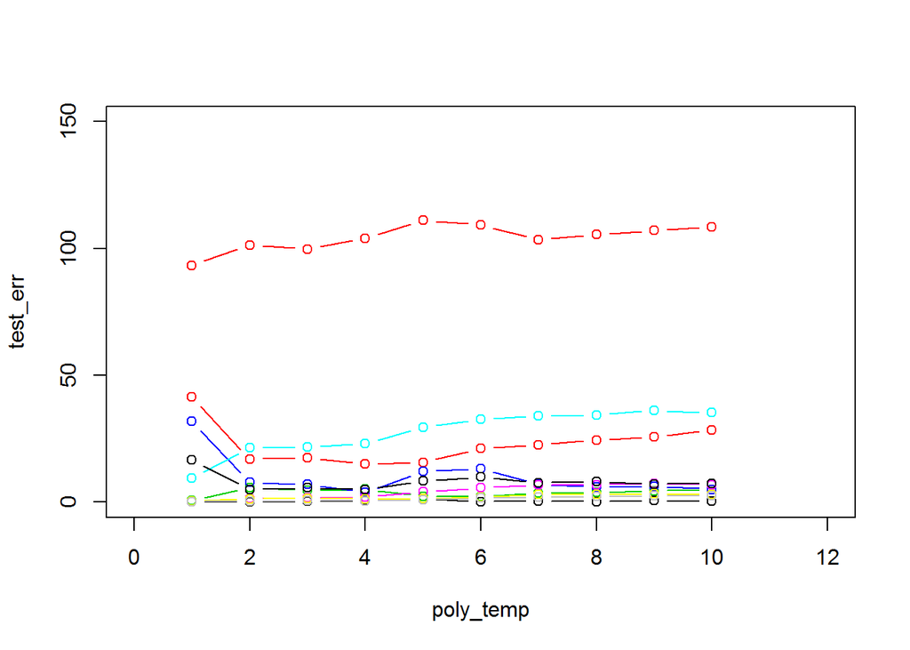

```r
library(ISLR)
make_LOOCV_poly <- function(n, train_index){
  poly_temp <- NULL
  test_err <- NULL
  for (i in 1:n ) {
    temp.lm = lm(mpg ~ poly(horsepower, i), data = Auto, subset = train_index)
    # print (summary(temp.lm)$coef)
    temp.pre = predict(temp.lm, Auto[!train_index, ])
    test_err <- c(test_err, mean((Auto[!train_index, "mpg"] - temp.pre)^2))
    poly_temp <- c(poly_temp, i)
  }

  return (temp_data <- data.frame("poly_temp" = poly_temp, "test_err" = test_err))
}

make_LOOCV_plot <- function() {
  for (i in 1:10){
    set.seed(i)
    train_index_0 <- sample(1:nrow(Auto), 1, replace = FALSE)
    train_index <- sample(TRUE, size = nrow(Auto), replace = TRUE)
    train_index[train_index_0] <- FALSE

    temp_data <- make_LOOCV_poly(10, train_index)
    # print (temp_data)
    if (i == 1) {
      plot(test_err ~ poly_temp, type = 'b', data = temp_data, ylim = range(0, 150), xlim = range(0, 12))
    }
    else {
      lines(temp_data$poly_temp, temp_data$test_err, type = 'b', col=i)
    }
  }
}

make_LOOCV_plot()
```

#### 3. k-fold CV

```r
make_nFOLD_poly <- function(n, train_index){
  test.err <- NULL
  poly_temp <- NULL
  for ( i in 1:n ) {
    temp.lm <- lm(mpg ~ poly(horsepower, i), data = Auto, subset = train_index)
    temp.pre <- predict(temp.lm, data = Auto[!train_index, ])
    test.err <- c(test.err, (temp.pre - Auto[!train_index, 'mpg']) ^ 2)
    poly_temp <- c(poly_temp, i)
  }
  return (temp_data <- data.frame("poly_temp" = poly_temp, "test.err" = test.err))
}

# train_data(Auto)

rep(0, 10)
```

```
##  [1] 0 0 0 0 0 0 0 0 0 0
```

**Lab @ 5.1.3** page 207 *purpose:* to check if above is correct/ leverage the example’s method *question:* the first one is the example in the book, the later one is I tried. But the variation is very small, and I’m not sure if there is anything wrong here. If you make the fold increased, you will see the variation is also increased.

```r
library(boot)
set.seed(17)
cv.error.10 = rep(0, 10)
for ( i in 1:10 ) {
  glm.fit = glm(mpg ~ poly(horsepower, i), data = Auto)
  cv.error.10[i] = cv.glm(Auto, glm.fit, K= 10)$delta[1]
}
cv.error.10
```

```
##  [1] 24.20520 19.18924 19.30662 19.33799 18.87911 19.02103 18.89609
##  [8] 19.71201 18.95140 19.50196
```

```r
make_data_w_k_index <- function(origin_data, k){
  n <- sample(1:100, 1, replace = TRUE)
  set.seed(n)
  # print (n)
  train_index_0 <- rep_len(1:k, length.out = nrow(origin_data))
  train_index_0 <- sample(train_index_0, size = length(train_index_0), replace = FALSE)
  # print (head(train_index_0))
  origin_data_temp <- origin_data
  origin_data_temp["k_index"] = train_index_0
  # print (head(origin_data_temp, 2))
  return (origin_data_temp)
}

make_mFOLD_yPOLY <- function(m, y, data_w_k_index){
  cv.error.m <- NULL
  poly <- NULL
  for (n in 1:y) {
    temp.lm <- lm(mpg ~ poly(horsepower, n), data = data_w_k_index)
    cv.error.temp <- NULL
    # print (head(data_w_k_index$k_index))
    for (i in 1:m){
      temp.pre <- predict(temp.lm, data_w_k_index[which(data_w_k_index$k_index == i), ])
      temp.error <- mean((temp.pre - data_w_k_index[which(data_w_k_index$k_index == i), "mpg"])^2)
      cv.error.temp <- c(cv.error.temp, temp.error)
    }
    cv.error.m <- c(cv.error.m, mean(cv.error.temp))
    # print(cv.error.m)
    poly <- c(poly, n)
  }
  data.temp <- data.frame("poly" = poly, "cv.err" = cv.error.m)
  # print (data.temp)
  return (data.temp)
}

print(make_mFOLD_yPOLY(10, 2, make_data_w_k_index(Auto, 10)))
```

```
##   poly   cv.err
## 1    1 23.93277
## 2    2 18.96989
```

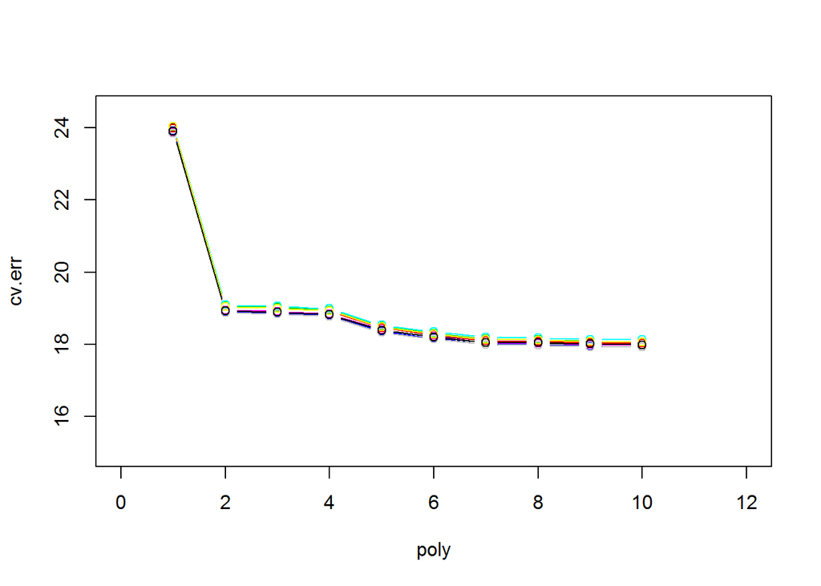

```r
cv.data_temp <- NULL
for (i in 1:9){
  cv.data_temp <- make_mFOLD_yPOLY(40, 10, make_data_w_k_index(Auto, 40))
  if (i == 1){
    plot(cv.err ~ poly, data = cv.data_temp, type = 'b', ylim = range(15, 24.5), xlim = range(0, 12))
  }
  else {
    lines(cv.data_temp$poly, cv.data_temp$cv.err, col = i, type = 'b')
  }
}
```

#### 4. bootstrap

**example @ lab page 208**  
*purpose:* to familiar with the bootstrap  
*method:* 1. make function; 2. use boot() function.  
*function of alpha:*

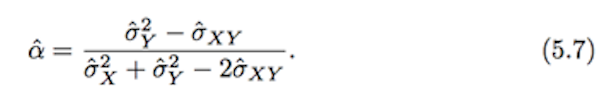

*data:* Portforlio  
*Note:* It seems the photo is just one example in the book, not the function for the bootstrap

```r
alpha.fn = function(data, index) {
  X = data$X[index]
  Y = data$Y[index]
  return ((var(Y) - cov(X, Y)) / (var(X) + var(Y) - 2*cov(X, Y)))
}

alpha.fn(Portfolio, 1:100)
```

```
## [1] 0.5758321
```

```r
set.seed(1)
alpha.fn(Portfolio, sample(100, 100, replace = T))
```

```
## [1] 0.5963833
```

```r
boot(Portfolio, alpha.fn, R = 1000)
```

```
##
## ORDINARY NONPARAMETRIC BOOTSTRAP
##
##
## Call:
## boot(data = Portfolio, statistic = alpha.fn, R = 1000)
##
##
## Bootstrap Statistics :
##      original        bias    std. error
## t1* 0.5758321 -7.315422e-05  0.08861826
```

*method:* still bootstrap *data:* Auto *question:* Even if the alpha is calculated, how could we use this data to do further prediction? *comparision:* There are some comparison between the bootstrap and the lm function between the mpg ~ horsepower, in the Auto data.

```r
alpha.mpg = function(data, index) {
  X = data$horsepower[index]
  Y = data$mpg[index]
  return ((var(Y)-cov(X,Y)) / (var(X) + var(Y) - 2*cov(X, Y)))
}
alpha.mpg(Auto, 1:nrow(Auto))
```

```
## [1] 0.1466399
```

```r
boot(Auto, alpha.mpg, R = 1000)
```

```
##
## ORDINARY NONPARAMETRIC BOOTSTRAP
##
##
## Call:
## boot(data = Auto, statistic = alpha.mpg, R = 1000)
##
##
## Bootstrap Statistics :
##      original       bias    std. error
## t1* 0.1466399 0.0002058865 0.006050316
```

```r
library(ISLR)
set.seed(1)
boot.fn = function(data, index)
  return (coef(lm(mpg~horsepower, data = data, subset = index)))
boot.fn(Auto, 1:392)
```

```
## (Intercept)  horsepower
##  39.9358610  -0.1578447
```

```r
coef(lm(mpg~horsepower, data = Auto))
```

```
## (Intercept)  horsepower
##  39.9358610  -0.1578447
```

```r
nrow(Auto)
```

```
## [1] 392
```

```r
set.seed(1)
boot.fn(Auto, sample(392, 392, replace = TRUE))
```

```
## (Intercept)  horsepower
##  38.7387134  -0.1481952
```

```r
# get the coef from Bootstrap
set.seed(1)
library (boot)
boot(Auto, boot.fn, 1000)
```

```
##
## ORDINARY NONPARAMETRIC BOOTSTRAP
##
##
## Call:
## boot(data = Auto, statistic = boot.fn, R = 1000)
##
##
## Bootstrap Statistics :
##       original        bias    std. error
## t1* 39.9358610  0.0269563085 0.859851825
## t2* -0.1578447 -0.0002906457 0.007402954
```

```r
# get the coef from the lm function
summary(lm(mpg~horsepower, data = Auto))$coef
```

```
##               Estimate  Std. Error   t value      Pr(>|t|)
## (Intercept) 39.9358610 0.717498656  55.65984 1.220362e-187
## horsepower  -0.1578447 0.006445501 -24.48914  7.031989e-81
```

```r
# continue compare the boot with lm with quandratic
boot.fn2 = function(data, index)
  return (coef(lm(mpg ~ horsepower + I(horsepower ^ 2), data = data, subset = index)))
set.seed(1)
boot(Auto, boot.fn2, 1000)
```

```
##
## ORDINARY NONPARAMETRIC BOOTSTRAP
##
##
## Call:
## boot(data = Auto, statistic = boot.fn2, R = 1000)
##
##
## Bootstrap Statistics :
##         original        bias     std. error
## t1* 56.900099702  6.098115e-03 2.0944855842
## t2* -0.466189630 -1.777108e-04 0.0334123802
## t3*  0.001230536  1.324315e-06 0.0001208339
```

```r
# boot.fn2(Auto,sample(392, 392, replace = TRUE))
summary(lm(mpg ~ horsepower + I(horsepower ^ 2), data = Auto))$coef
```

```
##                     Estimate   Std. Error   t value      Pr(>|t|)
## (Intercept)     56.900099702 1.8004268063  31.60367 1.740911e-109
## horsepower      -0.466189630 0.0311246171 -14.97816  2.289429e-40
## I(horsepower^2)  0.001230536 0.0001220759  10.08009  2.196340e-21
```